# **DeepFake: An Introduction**

DeepFakes refer to synthetic media where an individual's likeness is replaced with someone else's using artificial intelligence and deep learning techniques, particularly Generative Adversarial Networks (GANs). This technology can create highly realistic but fake images, audio, and videos, posing both innovative opportunities and significant ethical challenges.

Key Applications and Concerns:

- Applications: Entertainment (special effects), education, satire, and art.
- Concerns: Misinformation, privacy violations, political manipulation, cyberbullying, and harassment.
- In this notebook, we will explore how to detect and analyze DeepFakes using machine learning techniques.

Setting Up the Environment First, let's set up the necessary libraries and configurations:

[figure not shown]

### **Setting Up the Environment**

First, let's set up the necessary libraries and configurations:

### **Setup for Image Classification Pipeline with TensorFlow and Keras**

```python
import tensorflow as tf
from keras import layers
# from keras.preprocessing.image import ImageDataGenerator
from keras.models import Sequential
from keras.layers import Conv2D, MaxPooling2D, Flatten, Dense, BatchNormalization, Dropout
import numpy as np
import cv2
from tensorflow.keras import layers
from tensorflow.keras.applications import ResNet50
from tensorflow.keras.callbacks import Callback, ModelCheckpoint
from tensorflow.keras.preprocessing.image import ImageDataGenerator, load_img
from tensorflow.keras.models import Sequential
from tensorflow.keras.optimizers import Adam
import matplotlib.pyplot as plt
import matplotlib.image as mpimg
import pandas as pd
from sklearn.model_selection import train_test_split
from sklearn import metrics
from tensorflow.keras.callbacks import Callback , ReduceLROnPlateau , ModelCheckpoint, CSVLogger
from sklearn.metrics import cohen_kappa_score, accuracy_score
from tensorflow.keras.losses import categorical_crossentropy as logloss
from tensorflow.keras.metrics import categorical_accuracy
import pandas as pd
import os
from PIL import Image
import scipy
from sklearn import metrics
from sklearn.model_selection import train_test_split
import json
```

[output not shown]

### **Preparing the Data**

We will use an example dataset for demonstration purposes. Ensure your dataset is uploaded and the directory paths are correctly specified.

```python
# Defining directory paths
train_dir = '/kaggle/input/deepfake-and-real-images/Dataset/Train'
valid_dir = '/kaggle/input/deepfake-and-real-images/Dataset/Validation'
test_dir = '/kaggle/input/deepfake-and-real-images/Dataset/Test'
```

```python
# Importing necessary libraries for image handling and plotting
import matplotlib.pyplot as plt
import matplotlib.image as mpimg
import random
import os

# Function to view a random image from a specified directory
def view_random_image(target_dir, target_class):
    # Construct the path to the target class folder
    target_folder = target_dir + "/" + target_class
    print(f"Target folder: {target_folder}")  # Print the path for debugging

    # Select one random image from the target folder
    random_image = random.sample(os.listdir(target_folder), 1)

    # Read the selected image
    img = mpimg.imread(target_folder + "/" + random_image[0])

    # Display the image using matplotlib
    plt.imshow(img)
    plt.title(target_class)  # Set the title of the plot to the class name
    plt.axis("off")  # Turn off axis ticks and labels

    # Print the shape of the image (dimensions and channels) for debugging
    print(f"Image shape: {img.shape}")

    # Return the image array
    return img

# Example usage of the function (currently commented out)
# img = view_random_image(target_dir=train_dir, target_class="Real")
```

# **Setting Up Image Data Generators for Augmentation and Preprocessing in TensorFlow**

```python
# Importing the ImageDataGenerator class for image data preprocessing and augmentation
from tensorflow.keras.preprocessing.image import ImageDataGenerator

# Setting a random seed for reproducibility
tf.random.set_seed(42)

# Configuring the data augmentation for training images
train_datagen = ImageDataGenerator(rescale=1./255,          # Normalize pixel values to [0, 1]
    rotation_range=20,                                       # Randomly rotate images by up to 20 degrees
    width_shift_range=0.2,                                  # Randomly shift images horizontally by 20% of the width
    height_shift_range=0.2,                                 # Randomly shift images vertically by 20% of the height
    shear_range=0.2,                                        # Randomly apply shear transformations
    zoom_range=0.2,                                         # Randomly zoom in on images by 20%
    horizontal_flip=True)                                   # Randomly flip images horizontally

# Configuring the validation data generator (no augmentation, only normalization)
valid_datagen = ImageDataGenerator(rescale=1./255)          # Normalize pixel values to [0, 1]

# Configuring the test data generator (no augmentation, only normalization)
test_datagen = ImageDataGenerator(rescale=1./255)           # Normalize pixel values to [0, 1]

# Loading training data from the specified directory
train_data = train_datagen.flow_from_directory(train_dir,   # Directory containing training images
                                               batch_size=32,  # Number of images to yield per batch
                                               target_size=(224, 224),  # Resize images to 224x224 pixels
                                               class_mode="binary",  # Binary classification (two classes)
                                               seed=42)  # Ensure reproducibility

# Loading validation data from the specified directory
valid_data = valid_datagen.flow_from_directory(valid_dir,   # Directory containing validation images
                                               batch_size=32,  # Number of images to yield per batch
                                               target_size=(224, 224),  # Resize images to 224x224 pixels
                                               class_mode="binary",  # Binary classification (two classes)
                                               seed=42)  # Ensure reproducibility

# Loading test data from the specified directory
test_data = test_datagen.flow_from_directory(test_dir,      # Directory containing test images
                                               batch_size=1,   # Number of images to yield per batch (1 for test)
                                               target_size=(224, 224),  # Resize images to 224x224 pixels
                                               class_mode="binary",  # Binary classification (two classes)
                                               shuffle=False,  # Do not shuffle test data
                                               seed=42)  # Ensure reproducibility
```

```
Found 140002 images belonging to 2 classes.
Found 39428 images belonging to 2 classes.
Found 10905 images belonging to 2 classes.
```

# **CNN model (model_1)**

using TensorFlow/Keras with a Tiny VGG-like architecture. It's configured for binary classification and uses image data generators (train_data and valid_data) for training and validation.

```python
# Import TensorFlow and set a random seed for reproducibility
tf.random.set_seed(42)

# Create a CNN model (similar to Tiny VGG architecture)
model_1 = tf.keras.models.Sequential([
  # First convolutional layer: 20 filters, 3x3 kernel, ReLU activation
  tf.keras.layers.Conv2D(filters=20,
                         kernel_size=3, # Kernel size can be (3, 3)
                         activation="relu",
                         input_shape=(224, 224, 3)), # Input shape specifies height, width, and color channels

  # Second convolutional layer: 20 filters, 3x3 kernel, ReLU activation
  tf.keras.layers.Conv2D(20, 3, activation="relu"),

  # Max pooling layer: downsample with a pool size of 2
  tf.keras.layers.MaxPool2D(pool_size=2, # Pool size can be (2, 2)
                             padding="valid"), # No padding; 'same' would pad to keep size

  # Third convolutional layer: 20 filters, 3x3 kernel, ReLU activation
  tf.keras.layers.Conv2D(20, 3, activation="relu"),

  # Fourth convolutional layer: 20 filters, 3x3 kernel, ReLU activation
  tf.keras.layers.Conv2D(20, 3, activation="relu"), # ReLU activation applied

  # Second max pooling layer: downsample with a pool size of 4
  tf.keras.layers.MaxPool2D(4),

  # Flatten layer: converts the 3D output to a 1D array
  tf.keras.layers.Flatten(),

  # Dense layer: 1 output unit with sigmoid activation for binary classification
  tf.keras.layers.Dense(1, activation="sigmoid") # Sigmoid output for binary classification
])

# Compile the model with binary crossentropy loss and Adam optimizer
model_1.compile(loss="binary_crossentropy", # Loss function for binary classification
                optimizer=tf.keras.optimizers.Adam(), # Optimizer
                metrics=["accuracy"]) # Metric to evaluate during training

# Fit the model on the training data
history_1 = model_1.fit(train_data,
                        epochs=5, # Number of epochs for training
                        steps_per_epoch=128, # Number of batches per epoch
                        validation_data=valid_data, # Validation data for evaluating the model
                        validation_steps=128) # Number of validation batches per epoch
```

```
  2/128 ━━━━━━━━━━━━━━━━━━━━ 6s 51ms/step - accuracy: 0.5703 - loss: 0.6913
```

[output not shown]

```
128/128 ━━━━━━━━━━━━━━━━━━━━ 126s 837ms/step - accuracy: 0.5256 - loss: 0.6933 - val_accuracy: 0.5591 - val_loss: 0.6858
128/128 ━━━━━━━━━━━━━━━━━━━━ 97s 767ms/step - accuracy: 0.5345 - loss: 0.6914 - val_accuracy: 0.5205 - val_loss: 0.6920
128/128 ━━━━━━━━━━━━━━━━━━━━ 97s 763ms/step - accuracy: 0.5587 - loss: 0.6861 - val_accuracy: 0.6028 - val_loss: 0.6627
128/128 ━━━━━━━━━━━━━━━━━━━━ 91s 713ms/step - accuracy: 0.6213 - loss: 0.6567 - val_accuracy: 0.6011 - val_loss: 0.6617
128/128 ━━━━━━━━━━━━━━━━━━━━ 83s 653ms/step - accuracy: 0.6099 - loss: 0.6592 - val_accuracy: 0.6138 - val_loss: 0.6541
```

```python
# Function to load and preprocess an image
def load_and_prep_image(filename, img_shape=224):
  # Print the filename for debugging
  print(filename)

  # Read the image file
  img = tf.io.read_file(filename)

  # Decode the image into a tensor with 3 color channels
  img = tf.image.decode_image(img, channels=3)

  # Resize the image to the specified shape (default 224x224)
  img = tf.image.resize(img, size=[img_shape, img_shape])

  # Normalize pixel values to the range [0, 1]
  img = img / 255.0

  return img  # Return the preprocessed image

# Print the first element of the test data (should be an image batch)
print(test_data[0])

# Print the entire test data generator object
print(test_data)

# Make a prediction using the trained model on the 9000th test sample
pred = model_1.predict(test_data[9000])

# Convert prediction to binary (1 if predicted probability > 0.50, else 0)
ctr = 1 if pred > 0.50 else 0

# Print a new line for readability
print()

# Output the prediction result
pred
```

[output not shown]

```
array([[0.43216518]], dtype=float32)
```

# **Evaluating Model Performance: Confusion Matrix and Metrics Calculation**

The code defines a function, `gen_test_data`, which evaluates the performance of a trained model on test data by generating predictions and various metrics. Key steps include:

1. **Predictions**: The model predicts outcomes on the test dataset.
2. **Confusion Matrix**: It computes and displays a confusion matrix to visualize prediction results.
3. **ROC AUC and Precision Scores**: It calculates and prints the ROC AUC score and average precision score to assess classification performance.
4. **Classification Report**: It provides a detailed classification report, including precision, recall, and F1-score.
5. **Model Evaluation**: Finally, it evaluates the model's accuracy on the test data and prints the result.

The function is then called to execute these evaluations for the trained model.

```
10905/10905 ━━━━━━━━━━━━━━━━━━━━ 79s 7ms/step
[[3678 1814]
 [2234 3179]]
```

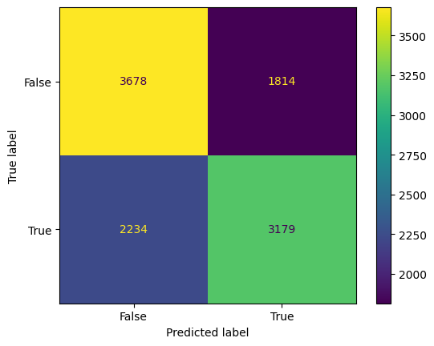

```
ROC AUC Score: 0.682961236531137
AP Score: 0.6517181471672031

              precision    recall  f1-score   support

           0       0.62      0.67      0.65      5492
           1       0.64      0.59      0.61      5413

    accuracy                           0.63     10905
   macro avg       0.63      0.63      0.63     10905
weighted avg       0.63      0.63      0.63     10905

10905/10905 ━━━━━━━━━━━━━━━━━━━━ 31s 3ms/step - accuracy: 0.6427 - loss: 0.6331
Final Test Accuracy = 62.879
```

```python
from sklearn import metrics
from sklearn.metrics import confusion_matrix

# Function to generate various performance metrics and a confusion matrix from model predictions
def gen_test_data(model):
    # Generate predictions from the model on the test data
    y_pred = model.predict(test_data)

    # Get the true labels from the test data
    y_test = test_data.classes

    # Convert predicted probabilities to binary labels (1 if probability > 0.5, else 0)
    y_pred_labels = (y_pred > 0.5).astype(np.float32)

    # Calculate the confusion matrix based on true and predicted labels
    confusion_mat = confusion_matrix(y_test, y_pred_labels)

    # Print the confusion matrix
    print(confusion_mat)

    # Display the confusion matrix visually
    cm_display = metrics.ConfusionMatrixDisplay(confusion_matrix=confusion_mat, display_labels=[False, True])
    cm_display.plot()  # Plot the confusion matrix
    plt.show()  # Show the plot

    # Calculate and print the ROC AUC score
    print("ROC AUC Score:", metrics.roc_auc_score(y_test, y_pred))

    # Calculate and print the Average Precision score
    print("AP Score:", metrics.average_precision_score(y_test, y_pred))

    # Print a detailed classification report including precision, recall, and F1-score
    print()
    print(metrics.classification_report(y_test, y_pred_labels))

    # Evaluate the model on the test data and print the final accuracy
    _, accu = model.evaluate(test_data)
    print('Final Test Accuracy = {:.3f}'.format(accu * 100))  # Format and print accuracy

# Call the function to generate test data metrics for the trained model
gen_test_data(model_1)
```

- **Imports**: Loads TensorFlow, NumPy, and Keras for model management and image processing.
- **Model Saving**: Saves the trained model (`model_1`) in Keras format to a specified path.
- **Image Preprocessing**: Defines a function to read, decode, resize, and normalize an image for model input.
- **Load Test Image**: Loads and preprocesses a specific test image, adding a batch dimension.
- **Load Saved Model**: Loads the previously saved model from the specified path.
- **Output Comparison**: Asserts that predictions from the original and loaded models for the same input are approximately equal.
- **Success Confirmation**: Prints a message if the outputs match, confirming model integrity after saving and loading.

```python
import tensorflow as tf
import numpy as np
from tensorflow import keras

# Save the trained model in Keras format to the specified path
model_1.save("/kaggle/working/VGG_01_FINAL.keras")

# Function to load and preprocess an image
def load_and_prep_image(filename, img_shape=224):
    # Print the filename being loaded for debugging purposes
    print(f"Loading image: {filename}")
    # Read the image file
    img = tf.io.read_file(filename)
    # Decode the image into a tensor with 3 channels (RGB)
    img = tf.image.decode_image(img, channels=3)
    # Resize the image to the target shape
    img = tf.image.resize(img, size=[img_shape, img_shape])
    # Normalize pixel values to be in the range [0, 1]
    img = img / 255.0
    return img

# Load and preprocess a specific test image from the directory
test_img = load_and_prep_image(f"{test_dir}/Real/real_4.jpg")
# Add a batch dimension to the image tensor for model input
test_img = tf.expand_dims(test_img, axis=0)

# Load the saved model from the specified path
reconstructed_model = keras.models.load_model("/kaggle/working/VGG_01_FINAL.keras")

# Check if the predictions from the original and reconstructed models are similar
assert np.allclose(model_1.predict(test_img), reconstructed_model.predict(test_img)), "Outputs do not match!"
# Print a confirmation message if the outputs are the same
print("The original and reconstructed model outputs match.")
```

```
Loading image: /kaggle/input/deepfake-and-real-images/Dataset/Test/Real/real_4.jpg
1/1 ━━━━━━━━━━━━━━━━━━━━ 0s 357ms/step
1/1 ━━━━━━━━━━━━━━━━━━━━ 0s 262ms/step
The original and reconstructed model outputs match.
```

```python
from tensorflow.keras.models import load_model  # Import the function to load a Keras model

# Define the path to the saved model file
model_path = '/kaggle/working/VGG_01_FINAL.keras'

try:
    # Attempt to load the model from the specified path
    vgg_1 = load_model(model_path)
    print("Model loaded successfully.")  # Print success message if loading is successful
except Exception as e:
    # Print error message if there is an issue loading the model
    print(f"Error loading the model: {e}")
```

```
Model loaded successfully.
```

```
Loading image: /kaggle/input/deepfake-and-real-images/Dataset/Test/Real/real_4.jpg
1/1 ━━━━━━━━━━━━━━━━━━━━ 0s 261ms/step
[[0.6659157]]
```

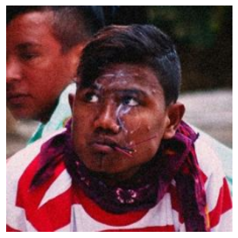

```python
import tensorflow as tf
import matplotlib.pyplot as plt

# Function to load and preprocess an image
def load_and_prep_image(filename, img_shape=224):
    # Print the filename being loaded for debugging purposes
    print(f"Loading image: {filename}")
    # Read the image file
    img = tf.io.read_file(filename)
    # Decode the image into a tensor with 3 channels (RGB)
    img = tf.image.decode_image(img, channels=3)
    # Resize the image to the target shape
    img = tf.image.resize(img, size=[img_shape, img_shape])
    # Normalize pixel values to be in the range [0, 1]
    img = img / 255.0
    return img

# Load and preprocess a specific test image from the directory
test_img_path = f"{test_dir}/Real/real_4.jpg"
test_img = load_and_prep_image(test_img_path)
# Add a batch dimension to the image tensor for model input
test_img_batch = tf.expand_dims(test_img, axis=0)

# Make a prediction with the loaded model
prediction = vgg_1.predict(test_img_batch)
# Print the prediction result
print(prediction)

# Display the processed image
plt.imshow(test_img)  # Show the image
plt.axis('off')  # Hide axes for a cleaner look
plt.show()  # Render the plot
```

### **Explanation:**

- **Imports**:
  - `tensorflow as tf`: Imports TensorFlow for model operations and image processing.
  - `matplotlib.pyplot as plt`: Imports Matplotlib for image visualization.
- **Function Definition (`load_and_prep_image`)**:
  - **Input**: Takes a `filename` (path to an image) and `img_shape` (desired image size, default is 224).
  - **Image Loading**:
    - Prints the name of the image file being loaded.
    - Reads the image file using `tf.io.read_file`.
  - **Image Decoding**:
    - Decodes the image into a tensor with 3 color channels (RGB).
  - **Image Resizing**:
    - Resizes the image to the specified dimensions (img_shape x img_shape).
  - **Normalization**:
    - Normalizes pixel values to be in the range [0, 1] by dividing by 255.
  - **Return**: Returns the preprocessed image tensor.
- **Load and Preprocess Test Image**:
  - Defines the path to the test image (`real_4.jpg`) using `test_dir`.
  - Calls `load_and_prep_image` to load and preprocess the image, storing the result in `test_img`.
  - Adds a batch dimension to the image tensor for compatibility with the model's input using `tf.expand_dims`.
- **Make Prediction**:
  - Uses the loaded model (`vgg_1`) to make a prediction on the preprocessed image batch (`test_img_batch`).
  - Prints the prediction result.

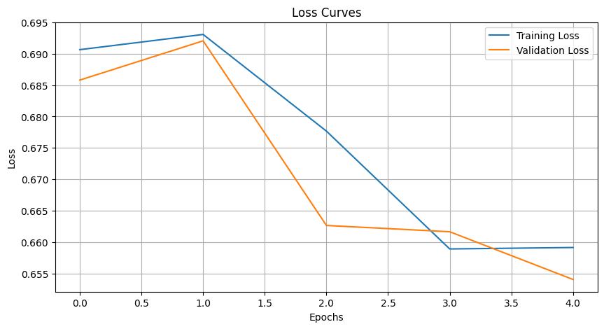

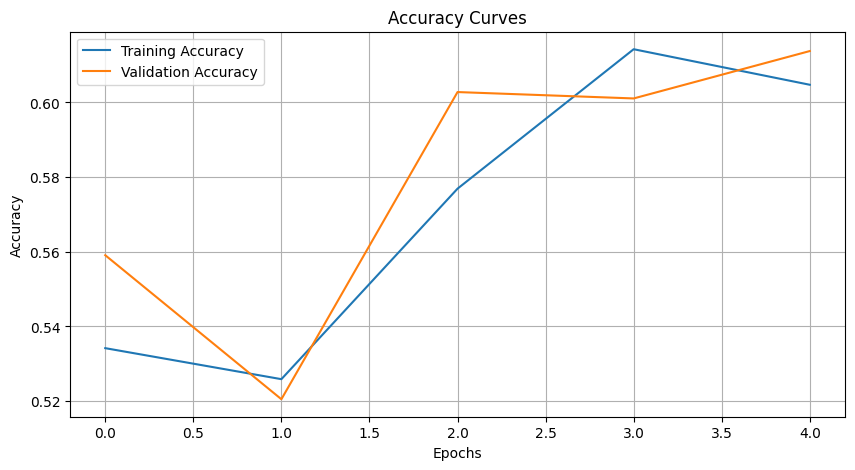

```python
import matplotlib.pyplot as plt  # Import matplotlib for plotting

# Function to plot loss and accuracy curves separately
def plot_loss_curves(history):

    # Extract loss and accuracy data from training history
    loss = history.history['loss']  # Training loss values
    val_loss = history.history['val_loss']  # Validation loss values

    accuracy = history.history['accuracy']  # Training accuracy values
    val_accuracy = history.history['val_accuracy']  # Validation accuracy values

    epochs = range(len(loss))  # Create a range for the number of epochs

    # Plot loss
    plt.figure(figsize=(10, 5))  # Set figure size for loss plot
    plt.plot(epochs, loss, label='Training Loss')  # Plot training loss
    plt.plot(epochs, val_loss, label='Validation Loss')  # Plot validation loss
    plt.title('Loss Curves')  # Set title for the loss plot
    plt.xlabel('Epochs')  # Label for the x-axis
    plt.ylabel('Loss')  # Label for the y-axis
    plt.legend()  # Display legend for the plot
    plt.grid(True)  # Add grid for better readability
    plt.show()  # Show the loss plot

    # Plot accuracy
    plt.figure(figsize=(10, 5))  # Set figure size for accuracy plot
    plt.plot(epochs, accuracy, label='Training Accuracy')  # Plot training accuracy
    plt.plot(epochs, val_accuracy, label='Validation Accuracy')  # Plot validation accuracy
    plt.title('Accuracy Curves')  # Set title for the accuracy plot
    plt.xlabel('Epochs')  # Label for the x-axis
    plt.ylabel('Accuracy')  # Label for the y-axis
    plt.legend()  # Display legend for the plot
    plt.grid(True)  # Add grid for better readability
    plt.show()  # Show the accuracy plot

# Usage example (assuming `history_1` is your training history):
plot_loss_curves(history_1)  # Call the function with training history
```

### **Explanation:**

```python
# Import necessary libraries and modules
from tensorflow.keras.optimizers import Adam  # Optimizer for model training
from tensorflow.keras.layers import Dense, Flatten, Conv2D, MaxPool2D, Activation  # Layers for the model
from tensorflow.keras import Sequential  # Sequential model

tf.random.set_seed(42)  # Set random seed for reproducibility

# Define the model architecture
model_2 = Sequential([
    Conv2D(20, 3, activation='relu', input_shape=(224, 224, 3)),  # First convolutional layer with ReLU activation
    MaxPool2D(pool_size=2),  # Max pooling layer to reduce the feature map size by half
    Conv2D(20, 3, activation='relu'),  # Second convolutional layer with ReLU activation
    MaxPool2D(),  # Max pooling layer
    Conv2D(20, 3, activation='relu'),  # Third convolutional layer with ReLU activation
    MaxPool2D(),  # Max pooling layer
    Flatten(),  # Flatten the output to feed into the dense layer
    Dense(1, activation='sigmoid')  # Output layer for binary classification
])

# Compile the model with loss function, optimizer, and evaluation metrics
model_2.compile(loss='binary_crossentropy',  # Binary cross-entropy loss for binary classification
                optimizer=Adam(),  # Adam optimizer
                metrics=['accuracy'])  # Track accuracy during training

# Fit the model on training data with validation
history_2 = model_2.fit(train_data,  # Training data
                        epochs=6,  # Number of training epochs
                        steps_per_epoch=256,  # Number of steps per epoch
                        validation_data=valid_data,  # Validation data
                        validation_steps=256)  # Number of validation steps
```

```
256/256 ━━━━━━━━━━━━━━━━━━━━ 208s 779ms/step - accuracy: 0.5232 - loss: 0.6953 - val_accuracy: 0.5448 - val_loss: 0.6835
256/256 ━━━━━━━━━━━━━━━━━━━━ 196s 767ms/step - accuracy: 0.5831 - loss: 0.6738 - val_accuracy: 0.5817 - val_loss: 0.6773
256/256 ━━━━━━━━━━━━━━━━━━━━ 194s 762ms/step - accuracy: 0.6109 - loss: 0.6599 - val_accuracy: 0.6097 - val_loss: 0.6527
256/256 ━━━━━━━━━━━━━━━━━━━━ 185s 727ms/step - accuracy: 0.6150 - loss: 0.6493 - val_accuracy: 0.6366 - val_loss: 0.6317
256/256 ━━━━━━━━━━━━━━━━━━━━ 167s 656ms/step - accuracy: 0.6277 - loss: 0.6404 - val_accuracy: 0.6356 - val_loss: 0.6398
  7/256 ━━━━━━━━━━━━━━━━━━━━ 5s 20ms/step - accuracy: 0.6895 - loss: 0.6390
```

```
256/256 ━━━━━━━━━━━━━━━━━━━━ 162s 635ms/step - accuracy: 0.6466 - loss: 0.6346 - val_accuracy: 0.6307 - val_loss: 0.6336
```

### **Explanation:**

1. **Library Imports**:
   - The code imports necessary components from TensorFlow's Keras API, which is used for building and training neural networks.
2. **Random Seed**:
   - `tf.random.set_seed(42)`: This sets a random seed for reproducibility, ensuring that the results can be replicated across different runs.
3. **Model Architecture**:
   - A Sequential model (`model_2`) is defined using a stack of layers:
     - **Conv2D Layers**: These are convolutional layers that apply filters to the input images. Each layer uses ReLU (Rectified Linear Unit) activation to introduce non-linearity.
     - **MaxPool2D Layers**: These layers perform max pooling, reducing the spatial dimensions of the feature maps by half (or downsampling) to reduce computational load and prevent overfitting.
     - **Flatten Layer**: This layer flattens the output of the last convolutional layer into a one-dimensional array to prepare it for the dense layer.
     - **Dense Layer**: This is the output layer with a single neuron using the sigmoid activation function, suitable for binary classification tasks (outputting probabilities between 0 and 1).
4. **Model Compilation**:
   - The model is compiled with:
     - **Loss Function**: `binary_crossentropy`, which is appropriate for binary classification problems.
     - **Optimizer**: The Adam optimizer, known for its efficiency and effectiveness in training deep learning models.
     - **Metrics**: The model will track accuracy during training.
5. **Model Training**:
   - The model is trained using the `fit` method:
     - **Training Data**: Provided through `train_data`.
     - **Number of Epochs**: The model will train for 6 epochs.
     - **Steps per Epoch**: The number of batches to be processed in one epoch (256 in this case).
     - **Validation Data**: Used to evaluate the model's performance on unseen data after each epoch.
     - **Validation Steps**: Number of batches for validation (256).

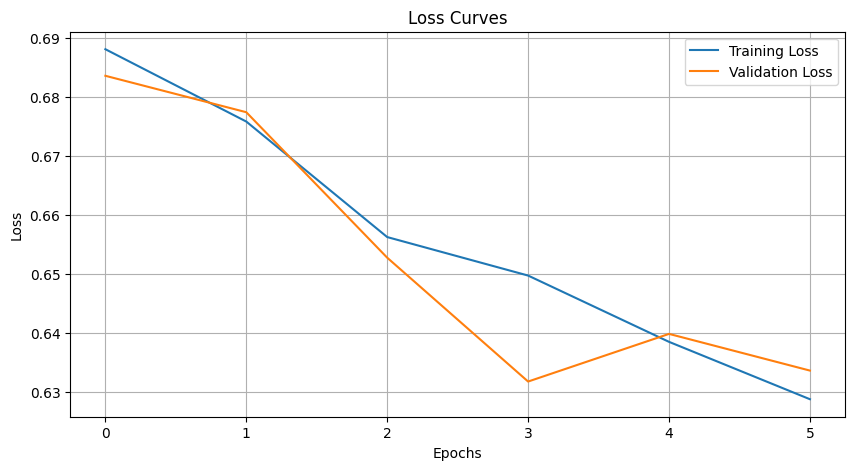

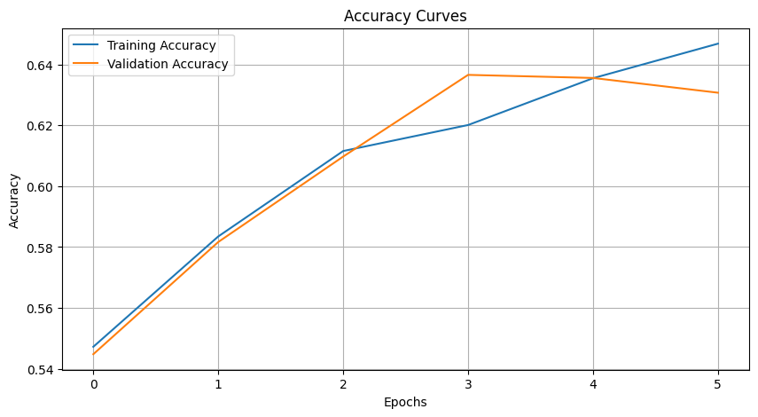

```python
# Usage example (assuming `history_2` is your training history):
plot_loss_curves(history_2)  # Call the function with training history
```

```python
# Save the trained model in HDF5 format
model_2.save("VGG_2_FINAL.h5")
```

```
10905/10905 ━━━━━━━━━━━━━━━━━━━━ 39s 3ms/step
[[2137 3355]
 [ 669 4744]]
```

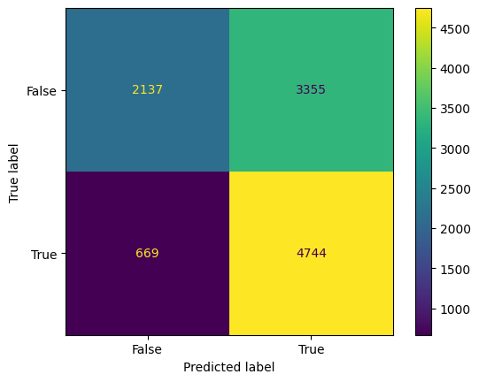

```
ROC AUC Score: 0.7108320329965532
AP Score: 0.6760556589866396

              precision    recall  f1-score   support

           0       0.76      0.39      0.52      5492
           1       0.59      0.88      0.70      5413

    accuracy                           0.63     10905
   macro avg       0.67      0.63      0.61     10905
weighted avg       0.67      0.63      0.61     10905

10905/10905 ━━━━━━━━━━━━━━━━━━━━ 30s 3ms/step - accuracy: 0.4463 - loss: 0.7533
Final Test Accuracy = 63.099
```

```python
# Assuming gen_test_data is defined to evaluate the model
gen_test_data(model_2)
```

```
1/1 ━━━━━━━━━━━━━━━━━━━━ 0s 328ms/step
1/1 ━━━━━━━━━━━━━━━━━━━━ 0s 21ms/step
Prediction for real image 1: [[0.4751619]]
Prediction for fake image 2: [[0.55380595]]
```

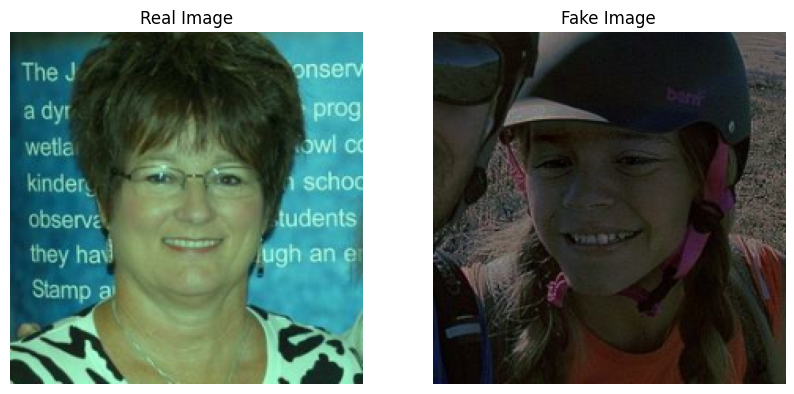

```python
import tensorflow as tf
import matplotlib.pyplot as plt

def load_and_prep_image(filename, img_shape=224):
    # Read in the target file (an image)
    # print(f"Loading image: {filename}")  # Commented out to hide loading message
    img = tf.io.read_file(filename)  # Read the image file

    img = tf.image.decode_image(img, channels=3)  # Decode the image into a 3-channel (RGB) format
    img = tf.image.resize(img, size=[img_shape, img_shape])  # Resize the image to the specified shape
    img = img / 255.0  # Normalize pixel values to the range [0, 1]

    return img

# Define your test directory (make sure this is set)
test_dir = "/kaggle/input/deepfake-and-real-images/Dataset/Test"

# Specify image paths for real and fake images
train_img_path_1 = f"{test_dir}/Real/real_10.jpg"  # Path to a real image
train_img_path_2 = f"{test_dir}/Fake/fake_100.jpg"  # Path to a fake image

# Load and preprocess the images
train_img_real_1 = load_and_prep_image(train_img_path_1)  # Load and prepare the real image
train_img_real_2 = load_and_prep_image(train_img_path_2)  # Load and prepare the fake image

# Expand dimensions to match model input shape (add batch dimension)
train_img_real_1 = tf.expand_dims(train_img_real_1, axis=0)
train_img_real_2 = tf.expand_dims(train_img_real_2, axis=0)

# Make predictions using the model
pred_1 = model_2.predict(train_img_real_1)  # Prediction for the real image
pred_2 = model_2.predict(train_img_real_2)  # Prediction for the fake image

# Print the predictions
print("Prediction for real image 1:", pred_1)
print("Prediction for fake image 2:", pred_2)

# Function to display images in a single row
def display_images_in_row(images, titles):
    plt.figure(figsize=(10, 5))  # Create a figure with specified size
    for i, image in enumerate(images):
        plt.subplot(1, len(images), i + 1)  # Create subplots in a single row
        plt.imshow(image)  # Display the image
        plt.title(titles[i])  # Set the title for the subplot
        plt.axis('off')  # Turn off axis numbers and ticks
    plt.show()  # Show the figure with the images

# Display the images in a single row
display_images_in_row(
    [tf.squeeze(train_img_real_1), tf.squeeze(train_img_real_2)],  # Remove batch dimension for display
    ["Real Image", "Fake Image"]  # Titles for the images
)
```

### **Explanation:**

```python
import tensorflow as tf
from tensorflow.keras import layers, Sequential
from tensorflow.keras.applications import ResNet50
from tensorflow.keras.optimizers import Adam

# Set a random seed for reproducibility
tf.random.set_seed(42)

# Assume train_data and valid_data are already defined and preprocessed

# Train the model using the fit method with optimized settings
history = model_resnet.fit(
    train_data,  # Prefetch data for performance
    epochs=2,  # Temporarily reduce the number of epochs for faster testing
    steps_per_epoch=32,  # Reduce the number of training steps per epoch
    validation_data=valid_data,  # Prefetch validation data
    validation_steps=32  # Reduce the number of validation steps per epoch
)
```

[output not shown]

### Explanation:

```python
# Usage example (assuming `history` is your training history):
plot_loss_curves(history)  # Call the function with training history
```

[output not shown]

```python
# Call the model on some dummy data to build it
dummy_data = tf.random.normal((1, 224, 224, 3))
_ = model_resnet(dummy_data)

# Save the model
model_resnet.save("/kaggle/working/Res_01_FINAL.keras")
```

```python
# Optional if above cell not working proper.
import keras
model_resnet.save("/kaggle/working/Res_01_FINAL.keras")
```

# **Random Forest classifier**

### 1. Import Required Libraries

- **os** and **random**: For handling file paths and selecting random samples.
- **numpy**: For numerical operations.
- **matplotlib**: For image plotting.
- **sklearn**: For machine learning and evaluation metrics.
- **tensorflow.keras**: For deep learning and image preprocessing.

```python
import os
import random
import numpy as np
import matplotlib.pyplot as plt
import matplotlib.image as mpimg
from sklearn.ensemble import RandomForestClassifier
from sklearn.metrics import confusion_matrix, classification_report, accuracy_score
from sklearn.preprocessing import LabelEncoder
from tensorflow.keras.applications import ResNet50
from tensorflow.keras.preprocessing.image import ImageDataGenerator, load_img
```

### 2. Define Directory Paths

```
train_dir = '/kaggle/input/deepfake-and-real-images/Dataset/Train'
valid_dir = '/kaggle/input/deepfake-and-real-images/Dataset/Validation'
test_dir = '/kaggle/input/deepfake-and-real-images/Dataset/Test'
```

- Set the paths to the training, validation, and test datasets.

```python
train_dir = '/kaggle/input/deepfake-and-real-images/Dataset/Train'
valid_dir = '/kaggle/input/deepfake-and-real-images/Dataset/Validation'
test_dir = '/kaggle/input/deepfake-and-real-images/Dataset/Test'
```

### 3. Function to View a Random Image

- **target_dir**: Directory containing images.
- **target_class**: Subdirectory for a specific class (e.g., "Real" or "Fake").
- Select a random image from the specified class directory and display it using `matplotlib`.

### 4. Display Random Images

- Display a random image from each specified directory and class.

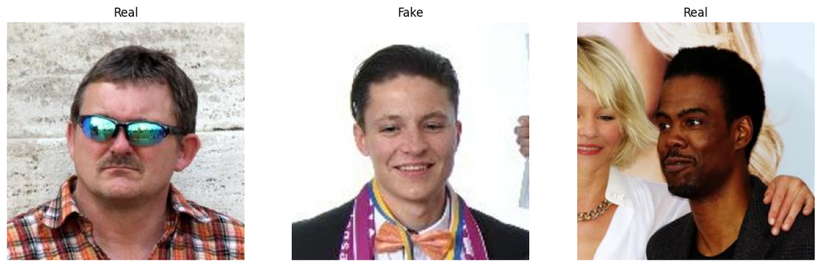

```python
# Function to view a random image from a specified directory
def view_random_images(target_dirs, target_classes):
    num_images = len(target_classes)
    fig, axes = plt.subplots(1, num_images, figsize=(15, 5))  # Adjust figsize as needed

    for i, (target_dir, target_class) in enumerate(zip(target_dirs, target_classes)):
        target_folder = os.path.join(target_dir, target_class)
        random_image = random.sample(os.listdir(target_folder), 1)
        img = mpimg.imread(os.path.join(target_folder, random_image[0]))
        axes[i].imshow(img)
        axes[i].set_title(target_class)
        axes[i].axis("off")

    plt.show()

# Display random images in a single row
view_random_images([train_dir, train_dir, valid_dir], ["Real", "Fake", "Real"])
```

### 5. Set Up ImageDataGenerators

- **rescale=1./255**: Normalize pixel values to the range [0, 1].

```python
datagen = ImageDataGenerator(rescale=1./255)
```

### 6. Function to Extract Features Using ResNet50

- **directory**: Path to the dataset directory.
- **num_samples**: Number of samples to process per class.
- **classes**: List of class labels.
- For each class, load images, preprocess them, extract features using ResNet50, and store the features and labels.

```python
def extract_features(directory, num_samples):
    features = []
    labels = []
    classes = ['Real', 'Fake']

    for class_label in classes:
        class_dir = directory + '/' + class_label
        for image_file in os.listdir(class_dir)[:num_samples]:
            image_path = class_dir + '/' + image_file
            image = load_img(image_path, target_size=(224, 224))
            image = np.array(image, dtype=np.float32)  # Ensure float32 type
            image = np.expand_dims(image, axis=0)
            image = datagen.standardize(image)
            features.append(model.predict(image)[0])
            labels.append(class_label)

    return np.array(features), np.array(labels)
```

### 7. Load ResNet50 Model for Feature Extraction

- Load the ResNet50 model pre-trained on ImageNet without the top classification layer.
- Use global average pooling to reduce the dimensions.

### 8. Extract Features from the Datasets

- Extract features from the training, validation, and test datasets using the `extract_features` function.

### 9. Encode Labels

- Encode class labels as integers for use in machine learning models.

### 10. Train Random Forest Classifier

- Initialize and train a Random Forest classifier using the extracted features.

```python
model = ResNet50(weights='imagenet', include_top=False, pooling='avg')
```

```
Downloading data from https://storage.googleapis.com/tensorflow/keras-applications/resnet/resnet50_weights_tf_dim_ordering_tf_kernels_notop.h5
94765736/94765736 ━━━━━━━━━━━━━━━━━━━━ 0s 0us/step
```

```python
num_samples_per_class = 100
X_train, y_train = extract_features(train_dir, num_samples_per_class)
X_valid, y_valid = extract_features(valid_dir, num_samples_per_class)
X_test, y_test = extract_features(test_dir, num_samples_per_class)
```

[output not shown]

[output cut: 545 more lines]

[output not shown]

```python
label_encoder = LabelEncoder()
y_train_encoded = label_encoder.fit_transform(y_train)
y_valid_encoded = label_encoder.transform(y_valid)
y_test_encoded = label_encoder.transform(y_test)
```

```python
rf_classifier = RandomForestClassifier(n_estimators=100, random_state=42)
rf_classifier.fit(X_train, y_train_encoded)
```

```
RandomForestClassifier(random_state=42)
```

### 11. Predict and Evaluate on Validation Data

- Predict labels for the validation data and print the accuracy score.

### 12. Predict and Evaluate on Test Data

- Predict labels for the test data and print the accuracy score.

```python
y_valid_pred = rf_classifier.predict(X_valid)
print("Validation Accuracy:", accuracy_score(y_valid_encoded, y_valid_pred))
```

```
Validation Accuracy: 0.625
```

```python
y_test_pred = rf_classifier.predict(X_test)
print("Test Accuracy:", accuracy_score(y_test_encoded, y_test_pred))
```

```
Test Accuracy: 0.62
```

### 13. Print Classification Report and Confusion Matrix

```
print("Classification Report:\n", classification_report(y_test_encoded, y_test_pred, target_names=label_encoder.classes_))
conf_mat = confusion_matrix(y_test_encoded, y_test_pred)
print("Confusion Matrix:\n", conf_mat)
```

- Print a detailed classification report and the confusion matrix for the test data.

```python
print("Classification Report:\n", classification_report(y_test_encoded, y_test_pred, target_names=label_encoder.classes_))
conf_mat = confusion_matrix(y_test_encoded, y_test_pred)
print("Confusion Matrix:\n", conf_mat)
```

```
Classification Report:
               precision    recall  f1-score   support

        Fake       0.61      0.69      0.64       100
        Real       0.64      0.55      0.59       100

    accuracy                           0.62       200
   macro avg       0.62      0.62      0.62       200
weighted avg       0.62      0.62      0.62       200

Confusion Matrix:
 [[69 31]
 [45 55]]
```

### 14. Plot Confusion Matrix

- Plot the confusion matrix using `matplotlib` for a visual representation of the model's performance.

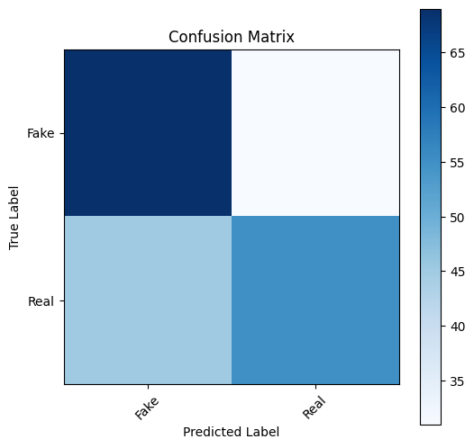

```python
plt.figure(figsize=(6, 6))
plt.imshow(conf_mat, cmap=plt.cm.Blues)
plt.title("Confusion Matrix")
plt.colorbar()
tick_marks = np.arange(len(label_encoder.classes_))
plt.xticks(tick_marks, label_encoder.classes_, rotation=45)
plt.yticks(tick_marks, label_encoder.classes_)
plt.xlabel('Predicted Label')
plt.ylabel('True Label')
plt.show()
```

### 2. Define Directory Paths and Extract Features

Ensure your directory paths and feature extraction functions are correctly set up as before:

### 3. Encode Labels and Train Models

Encode the labels and train both the Random Forest and Logistic Regression models:

### 4. Create and Plot the Confusion Matrix

Generate the confusion matrix for one of the models (e.g., Random Forest) and plot it with additional details:

### Explanation:

- **Generate Confusion Matrix**: Compute the confusion matrix for the Random Forest model predictions.
- **Plot Confusion Matrix**: Use `plt.imshow` to display the confusion matrix and add labels and a color bar.
- **Add Text Annotations**: Iterate over the confusion matrix to add text annotations for each cell.
- **Add Overall Accuracy and Class Information**: Calculate and display overall accuracy and the number of samples for each class on the right side of the plot using `plt.gcf().text`.

```python
train_dir = '/kaggle/input/deepfake-and-real-images/Dataset/Train'
valid_dir = '/kaggle/input/deepfake-and-real-images/Dataset/Validation'
test_dir = '/kaggle/input/deepfake-and-real-images/Dataset/Test'

def extract_features(directory, num_samples):
    features = []
    labels = []
    classes = ['Real', 'Fake']

    for class_label in classes:
        class_dir = directory + '/' + class_label
        for image_file in os.listdir(class_dir)[:num_samples]:
            image_path = class_dir + '/' + image_file
            image = load_img(image_path, target_size=(224, 224))
            image = np.array(image, dtype=np.float32)
            image = np.expand_dims(image, axis=0)
            image = datagen.standardize(image)
            features.append(model.predict(image)[0])
            labels.append(class_label)

    return np.array(features), np.array(labels)

model = ResNet50(weights='imagenet', include_top=False, pooling='avg')
datagen = ImageDataGenerator(rescale=1./255)

num_samples_per_class = 100
X_train, y_train = extract_features(train_dir, num_samples_per_class)
X_valid, y_valid = extract_features(valid_dir, num_samples_per_class)
X_test, y_test = extract_features(test_dir, num_samples_per_class)
```

[output not shown]

[output cut: 545 more lines]

[output not shown]

```python
label_encoder = LabelEncoder()
y_train_encoded = label_encoder.fit_transform(y_train)
y_valid_encoded = label_encoder.transform(y_valid)
y_test_encoded = label_encoder.transform(y_test)

rf_classifier = RandomForestClassifier(n_estimators=100, random_state=42)
rf_classifier.fit(X_train, y_train_encoded)
y_test_pred_rf = rf_classifier.predict(X_test)
accuracy_rf = accuracy_score(y_test_encoded, y_test_pred_rf)

logreg_classifier = LogisticRegression(random_state=42, max_iter=1000)
logreg_classifier.fit(X_train, y_train_encoded)
y_test_pred_lr = logreg_classifier.predict(X_test)
accuracy_lr = accuracy_score(y_test_encoded, y_test_pred_lr)
```

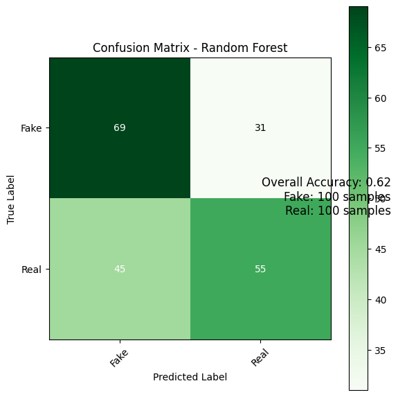

```python
# Generate confusion matrix for Random Forest
conf_mat = confusion_matrix(y_test_encoded, y_test_pred_rf)

# Plot confusion matrix with additional details
plt.figure(figsize=(6, 6))
plt.imshow(conf_mat, cmap=plt.cm.Greens)
plt.title("Confusion Matrix - Random Forest")
plt.colorbar()
tick_marks = np.arange(len(label_encoder.classes_))
plt.xticks(tick_marks, label_encoder.classes_, rotation=45)
plt.yticks(tick_marks, label_encoder.classes_)
plt.xlabel('Predicted Label')
plt.ylabel('True Label')

# Add text annotations in the confusion matrix
thresh = conf_mat.max() / 2.
for i, j in np.ndindex(conf_mat.shape):
    plt.text(j, i, format(conf_mat[i, j], 'd'),
             ha="center", va="center",
             color="white" if conf_mat[i, j] > thresh else "black")

# Add overall accuracy and class information
num_samples = len(y_test)
class_counts = np.bincount(y_test_encoded)
accuracy_text = f"Overall Accuracy: {accuracy_rf:.2f}\n"
for i, class_label in enumerate(label_encoder.classes_):
    accuracy_text += f"{class_label}: {class_counts[i]} samples\n"

plt.gcf().text(0.95, 0.5, accuracy_text, fontsize=12, va='center', ha='right')

plt.tight_layout()
plt.show()
```

# **Logistic Regression**

```python
# Import required libraries
import os
import random
import numpy as np
import matplotlib.pyplot as plt
import matplotlib.image as mpimg
from sklearn.linear_model import LogisticRegression
from sklearn.metrics import confusion_matrix, classification_report, accuracy_score
from sklearn.preprocessing import LabelEncoder
from tensorflow.keras.applications import ResNet50
from tensorflow.keras.preprocessing.image import ImageDataGenerator, load_img

# Defining directory paths
train_dir = '/kaggle/input/deepfake-and-real-images/Dataset/Train'
valid_dir = '/kaggle/input/deepfake-and-real-images/Dataset/Validation'
test_dir = '/kaggle/input/deepfake-and-real-images/Dataset/Test'
```

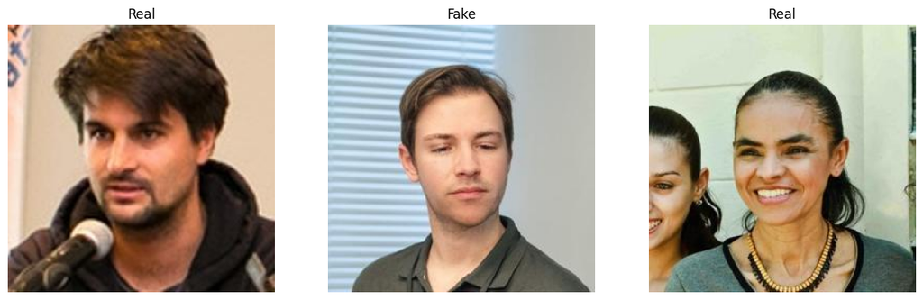

```python
# Function to view a random image from a specified directory
def view_random_images(target_dirs, target_classes):
    num_images = len(target_classes)
    fig, axes = plt.subplots(1, num_images, figsize=(15, 5))  # Adjust figsize as needed

    for i, (target_dir, target_class) in enumerate(zip(target_dirs, target_classes)):
        target_folder = os.path.join(target_dir, target_class)
        random_image = random.sample(os.listdir(target_folder), 1)
        img = mpimg.imread(os.path.join(target_folder, random_image[0]))
        axes[i].imshow(img)
        axes[i].set_title(target_class)
        axes[i].axis("off")

    plt.show()

# Display random images in a single row
view_random_images([train_dir, train_dir, valid_dir], ["Real", "Fake", "Real"])
```

```python
# Set up ImageDataGenerator for preprocessing
datagen = ImageDataGenerator(rescale=1./255)

# Function to extract features using ResNet50
def extract_features(directory, num_samples):
    features = []
    labels = []
    classes = ['Real', 'Fake']

    for class_label in classes:
        class_dir = directory + '/' + class_label
        for image_file in os.listdir(class_dir)[:num_samples]:
            image_path = class_dir + '/' + image_file
            image = load_img(image_path, target_size=(224, 224))
            image = np.array(image, dtype=np.float32)  # Ensure float32 type
            image = np.expand_dims(image, axis=0)
            image = datagen.standardize(image)
            features.append(model.predict(image)[0])
            labels.append(class_label)

    return np.array(features), np.array(labels)

# Load ResNet50 model for feature extraction
model = ResNet50(weights='imagenet', include_top=False, pooling='avg')
```

```python
# Extract features from the datasets
num_samples_per_class = 50
X_train, y_train = extract_features(train_dir, num_samples_per_class)
X_valid, y_valid = extract_features(valid_dir, num_samples_per_class)
X_test, y_test = extract_features(test_dir, num_samples_per_class)
```

[output not shown]

[output cut: 245 more lines]

[output not shown]

```python
# Encode labels
label_encoder = LabelEncoder()
y_train_encoded = label_encoder.fit_transform(y_train)
y_valid_encoded = label_encoder.transform(y_valid)
y_test_encoded = label_encoder.transform(y_test)

# Train Logistic Regression classifier
logreg_classifier = LogisticRegression(random_state=42, max_iter=1000)
logreg_classifier.fit(X_train, y_train_encoded)
```

```
LogisticRegression(max_iter=1000, random_state=42)
```

```python
# Predict and evaluate on validation data
y_valid_pred = logreg_classifier.predict(X_valid)
print("Validation Accuracy:", accuracy_score(y_valid_encoded, y_valid_pred))

# Predict and evaluate on test data
y_test_pred = logreg_classifier.predict(X_test)
print("Test Accuracy:", accuracy_score(y_test_encoded, y_test_pred))

# Print classification report and confusion matrix
print("Classification Report:\n", classification_report(y_test_encoded, y_test_pred, target_names=label_encoder.classes_))
conf_mat = confusion_matrix(y_test_encoded, y_test_pred)
print("Confusion Matrix:\n", conf_mat)
```

```
Validation Accuracy: 0.51
Test Accuracy: 0.55
Classification Report:
               precision    recall  f1-score   support

        Fake       0.55      0.56      0.55        50
        Real       0.55      0.54      0.55        50

    accuracy                           0.55       100
   macro avg       0.55      0.55      0.55       100
weighted avg       0.55      0.55      0.55       100

Confusion Matrix:
 [[28 22]
 [23 27]]
```

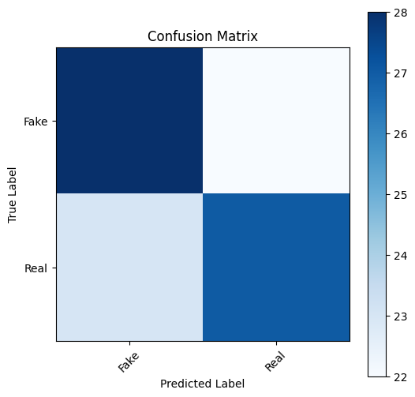

```python
# Plot confusion matrix
plt.figure(figsize=(6, 6))
plt.imshow(conf_mat, cmap=plt.cm.Blues)
plt.title("Confusion Matrix")
plt.colorbar()
tick_marks = np.arange(len(label_encoder.classes_))
plt.xticks(tick_marks, label_encoder.classes_, rotation=45)
plt.yticks(tick_marks, label_encoder.classes_)
plt.xlabel('Predicted Label')
plt.ylabel('True Label')
plt.show()
```

```python
label_encoder = LabelEncoder()
y_train_encoded = label_encoder.fit_transform(y_train)
y_valid_encoded = label_encoder.transform(y_valid)
y_test_encoded = label_encoder.transform(y_test)

# Train Random Forest Classifier
rf_classifier = RandomForestClassifier(n_estimators=100, random_state=42)
rf_classifier.fit(X_train, y_train_encoded)
y_test_pred_rf = rf_classifier.predict(X_test)
accuracy_rf = accuracy_score(y_test_encoded, y_test_pred_rf)

# Train Logistic Regression Classifier
logreg_classifier = LogisticRegression(random_state=42, max_iter=1000)
logreg_classifier.fit(X_train, y_train_encoded)
y_test_pred_lr = logreg_classifier.predict(X_test)
accuracy_lr = accuracy_score(y_test_encoded, y_test_pred_lr)
```

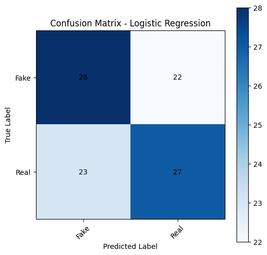

```python
# Generate confusion matrix for Logistic Regression
conf_mat_lr = confusion_matrix(y_test_encoded, y_test_pred_lr)

# Plot confusion matrix for Logistic Regression
plt.figure(figsize=(6, 6))
plt.imshow(conf_mat_lr, cmap=plt.cm.Blues)
plt.title("Confusion Matrix - Logistic Regression")
plt.colorbar()
tick_marks = np.arange(len(label_encoder.classes_))
plt.xticks(tick_marks, label_encoder.classes_, rotation=45)
plt.yticks(tick_marks, label_encoder.classes_)
plt.xlabel('Predicted Label')
plt.ylabel('True Label')

# Add text annotations
thresh = conf_mat_lr.max() / 2.
for i, j in np.ndindex(conf_mat_lr.shape):
    plt.text(j, i, format(conf_mat_lr[i, j], 'd'),
             ha="center", va="center",
             color="Black" if conf_mat_lr[i, j] > thresh else "white")

plt.show()
```